# Data Visualization for Univariate Data

# Plots for quantitative variables

For our first true plot we consider again the *quantitative variable* mpg. We want to know something about the distribution of the data values for this variable across all cars in the dataset, and the best way to see that visually is with a histogram.

A histogram is an example of a *geom* or *glyph*. We add these by appending a

+geom_something()

to our plot. In this case we add

+geom_histogram()

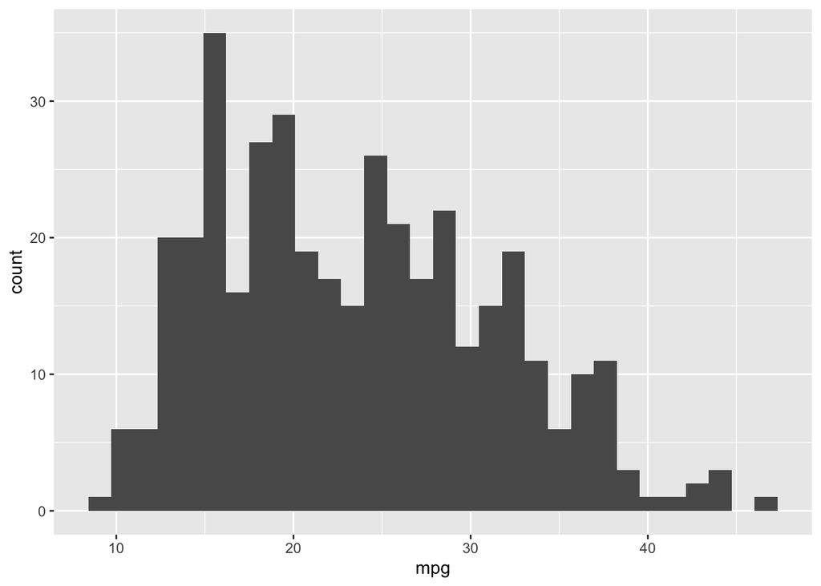

```r
MPG_Plot1<-MPG_Plot+geom_histogram()

MPG_Plot1
```

this plot has many drawbacks, but it is the default, we can fix some of these drawbacks with some simple options, these were referred to as *scales* above.

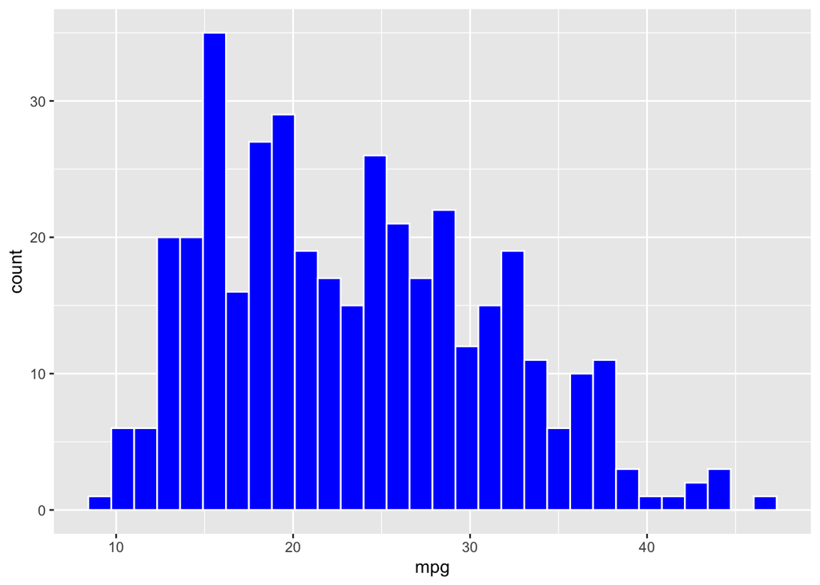

```r
MPG_Plot2<-MPG_Plot+geom_histogram(color="white",fill="blue")

MPG_Plot2
```

and even better

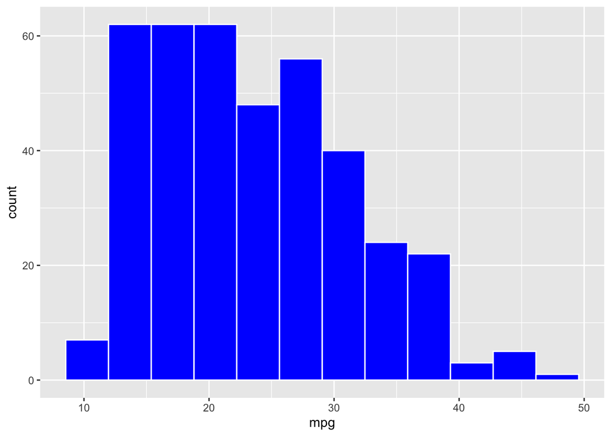

```r
MPG_Plot3<-MPG_Plot+geom_histogram(color="white",fill="blue",bins = 12)

MPG_Plot3
```

Now, the point of making this visualization is to say something about what it tells us about this variable. from this histogram what can we say about the mpgs for this set of vehicles?

One moral to the story for histograms, is that even though each histogram was made using the exact same set of data, the visual story that each histogram tells about the data emphasizes different aspects of the distribution of the data values across the range of values. For eaxmple in this case, using 30 bins is too many, and certainly 5 would be too few (see for yourself)

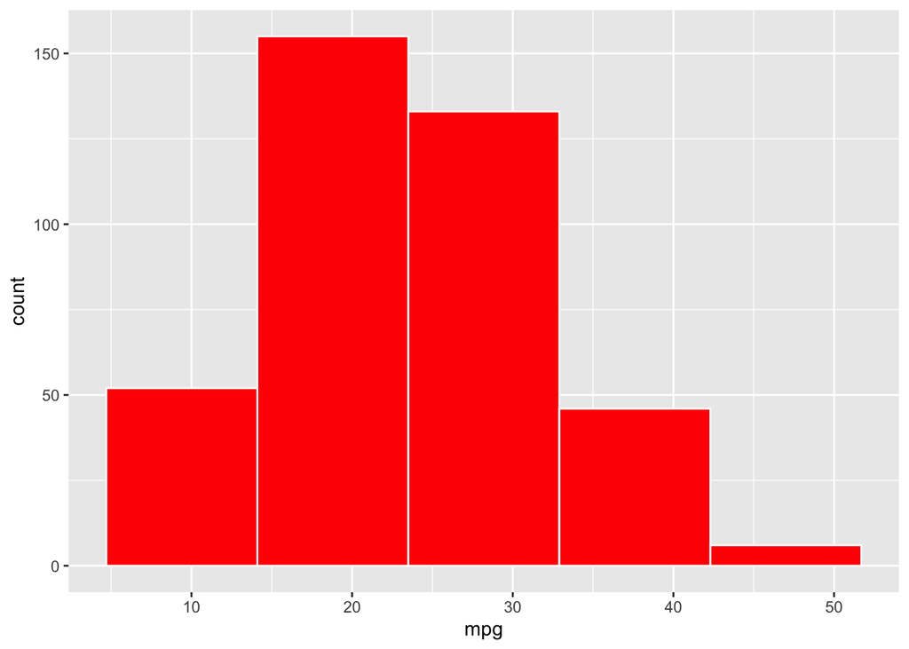

```r
MPG_Plot4<-MPG_Plot+geom_histogram(color="white",fill="red",bins = 5)

MPG_Plot4
```

# Plots for categorical variables

It does not look like any of the variables in this dataset are categorical, but that is because the categorical data was added as numbers.Type **help(Auto)** into the console and note what the help page tells us about the variables *origin* and *cylinders*.

Run the following code chunks.

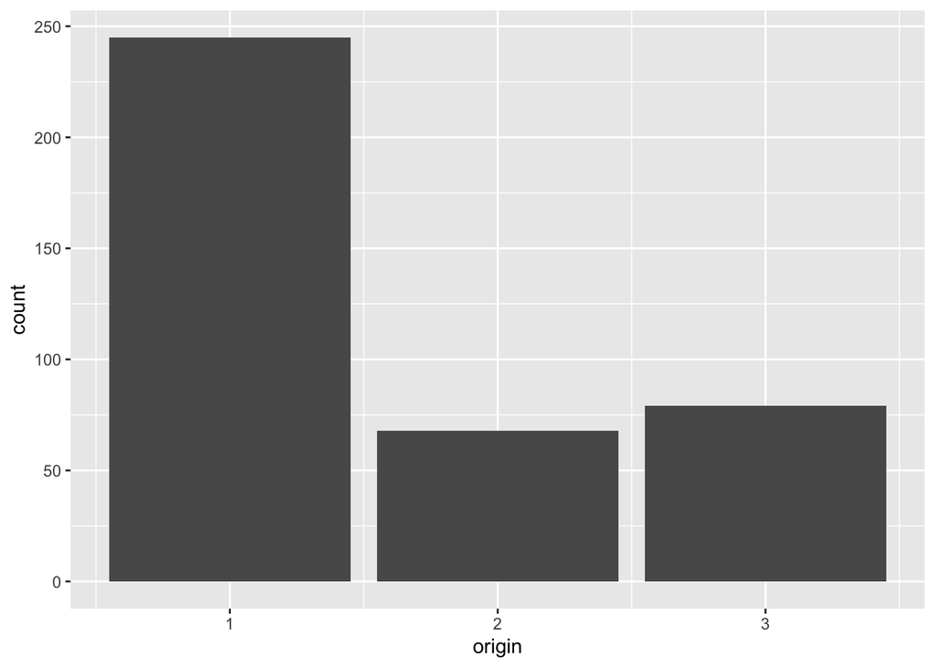

```r
OriginPlot<-ggplot(Auto1,aes(x=origin))

OriginPlot1<-OriginPlot+geom_bar()

OriginPlot1
```

[figure not shown]

```r
CylPlot<-ggplot(Auto1,aes(x=cylinders))

CylPlot1<-CylPlot+geom_bar()

CylPlot
```

Can you say what a barchart for a categorical variable is? What does it tell you (visually) about the “distribution” of the variable?

# Exercises

Do as many of these as you can in class. I will ask you to do some specific Exercises before the next class if you do not get to them in class. Some of these exercises will be included in the next HW, so if you finish them here you can simply copy your work into that HW. You should open a new R Markdown document and call it *Day 3 - Exercises*. Save this notebook in your course folder and do the exercises in this document.

## Exercise 1

Make appropriate histograms for the variables **acceleration** and **displacement** for this dataset. Use at least two different bin sizes (between 5 and 20 bins)for each histogram. As best you can (you don’t need to use precise statistical language unless you know it) describe the differences between the distribution of these two variables that are apparent from the histograms.

## Exercise 2

For this exercise we will use the dataset US_births_1994_2003 that we used extensively last class. before you can use this dataset, make sure you load in the package (fivethirtyeight) which contains the data.

Just for practice make barplots of the variables *day_of_week* and *date_of_month*. Even though we can make these plots they do not tell us anything new about these variables (why?).

Because the days of the month are numbers we could make a histogram of this variable. Do this now (using the defaults). What is going on? Can you explain? Can you fix this plot by changing the number of bins? Even though we can make a histogram for this variabe, say why this type of plot is not appropriate (useful?) in this case.

Also, make an appropriate histogram for the variable *births* and describe the distribution of this quantitative variable.